# 第4回 指数関数・対数関数の経済への応用１

経済学基礎数学II

第4回

指数関数・対数関数の  
経済への応用１

複利計算

経済学基礎数学II

第4回 — Topic01

単利と複利

利息に利息がつく

## 第4回の道のり

1

単利と複利

2

何年で $2$ 倍

3

連続複利

4

現在  
価値と実質

✎

ドリル4

いまココ — 振り返りとクイズから始めて、  
利息に利息がつく仕組みを $1$ 年ずつ追う

## 前回の振り返り

前回のポイント — $e$ と自然対数

Q: 前回作った $e$ と $\ln$ は、何だったか

- **$e$**: 年利 $100$ % で、  
  利息をつける回数を増やした行き先の倍率 $e = 2.718\ldots$
- **$\ln x$**: $e$ を何乗すると $x$ になるか。肩の数を前に降ろせる
- **$1.05^{n} = 2$**: 両辺の $\ln$ をとると肩の $n$ が降りる。値はこの回で出す

この回は、この道具を**お金**に向ける

## このトピックで学ぶこと

- **予想**：年 $4$ % で預けたお金が $2$ 倍になるのは何年後か
- **$1$ 年ずつ追う**：$1$・$2$・$3$ 年目の残高と利息を表と点で
- **式にする**：毎年同じ倍率をかけた形にまとめる
- **手で出す**：残高を STEP $3$ つで出す

使う道具はかけ算と累乗だけ。電卓はスマホの電卓でよい  
累乗は電卓の $x^{y}$ キーか、同じ数を $n$ 回かけて出す

## ✋ クイズ 2 倍になるまでの年数

クイズ

$100$ 万円を年 $4$ % で預ける。$2$ 倍の $200$ 万円に届くのは  
単利の $25$ 年より早いか、遅いか、同じか

単利

利息は**最初の $100$ 万円にだけ**つく

毎年 $4$ 万円ずつ。$25$ 年で $200$ 万円

複利

利息は**その時点の残高に**つく

ついた利息にも、また利息がつく

**残高**＝最初のお金と、それまでについた利息を合わせた、その時点の金額

⏸ PAUSE 動画を止めて $30$ 秒。**早い**・**遅い**・**同じ**。どれか選ぶ

## 1 年目から 3 年目の利息

[figure not shown]

利息にも利息がつくので、毎年の利息が少しずつ増える  
$2$ 年目の $4.16$ は $104 \times 0.04$、$3$ 年目の $4.3264$ は $108.16 \times 0.04$  
残高はどの年も、前の年の $1.04$ 倍

## 2 倍に届くのは 18 年目の年末

[figure not shown]

クイズの答えは**早い**。利息が毎年増えるので、$25$ 年より前に $2$ 倍に届く  
$17$ 年末は $194.79$ 万円 $18$ 年末は $202.58$ 万円

## 対数目盛で見た単利と複利

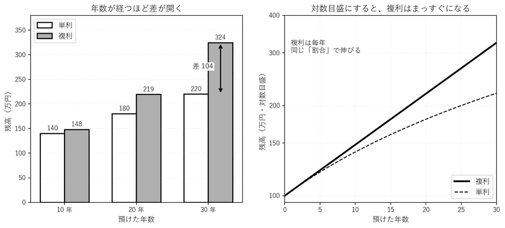

前に出てきた**対数目盛**＝同じ幅が同じ倍率になる縦軸（$2$ 倍ごとに同じ幅）  
複利は毎年 $1.04$ 倍なのでまっすぐ。単利は増える割合が下がって曲がる

## 複利の残高の式

毎年 $1.04$ 倍を $n$ 回かける。これを記号で書く

公式

$$n \text{ 年後の残高} = P(1+g)^{n}$$

- **$P$**：元金。最初に預けたお金
- **$g$**：年利率（前年比）。$4$ % なら $g = 0.04$ $1+g$ が $1$ 年の**倍率**
- **$n$**：年数。利息にも利息がつくこの預け方を**複利**という

今回は $P = 100,\ g = 0.04,\ n = 3$ で $100 \times 1.04^{3} = 112.4864$ 万円（表の $3$ 年目）  
図の $17$ 年末 $100 \times 1.04^{17} \approx 194.79$・$18$ 年末 $100 \times 1.04^{18} \approx 202.58$

## 複利の式が使える条件

次の $4$ つがそろっているときに、この式が使える

| 条件 | 意味 |
| --- | --- |
| 利率 $g$ が変わらない | 期間を通して同じ利率 |
| 期間の長さが等しい | 毎年 $1$ 回、年末につく |
| 元金も利息も引き出さない | ついた利息をそのまま預ける |
| 途中で預け足さない | 預け入れは最初の $1$ 回だけ。 税や手数料も考えない |

利率が途中で変わるなら、区切って掛ける  
最初の $2$ 年が $4$ % 次の $3$ 年が $3$ % なら $P(1.04)^{2}(1.03)^{3}$  
借金も、返さずに利息が元金に入るなら同じ式で増える

## 例題 4-1 春学期の表の作り直し

[figure not shown]

今度は春学期の表。$1$ 万円を年 $5$ % で $10$ 年  
単利 $15000$ 円 複利 $16288.95$ 円 差は $1288.95$ 円  
$35$ 年なら $27500$ 円 と約 $55160$ 円（$1.05^{35} \approx 5.516$）

## 例題 4-1 の計算

$10000 + 500n$

$= 10000(1 + 0.05n)$

単利。  
$500 = 10000 \times 0.05$

$10000(1 + 0.05 \times 10)$

$= 15000$

$n = 10$ を入れる

$1.05^{10}$

$\approx 1.62889$

複利。  
$1.05$ を $10$ 回かける  
（電卓の $x^{y}$ キー）

$10000 \times 1.05^{10}$

$\approx 16288.95$

$P(1+g)^{n}$ に $P = 10000$  
途中で丸めない

$16288.95 - 15000$

$= 1288.95$

$10$ 年での差。  
元金の $1$ 割を超える

単利は $500$ 円を $10$ 回足すだけ。複利は $1.05$ を $10$ 回かける

## ◼ 複利の残高の求め方

一般の式は $P(1+g)^{n}$。STEP は $3$ つ

手順

STEP 1元金 $P$、利率 $g$（% の数は $100$ で割る）、年数 $n$ を読み取る

STEP 2$1$ 年の倍率 $1+g$ を $n$ 乗して $(1+g)^{n}$ にする

STEP 3元金 $P$ に、その倍率を掛ける

| 今回は | STEP $1$ | STEP $2$ | STEP $3$ |
| --- | --- | --- | --- |
| $100$ 万円・$4$ %・$2$ 年 | $P = 100,\ g = 0.04,\ n = 2$ | $1.04^{2} = 1.0816$ | $100 \times 1.0816 = 108.16$ 万円 |

元金・利率・年数が変わっても、同じ $3$ STEP で出せる

## よくある失敗 % の入れ方

いまと同じ例 — $100$ 万円を年 $4$ % の複利で $2$ 年

✕ % をそのまま入れる

$100 \times (1+4)^{2} = 2500$

$4$ % は $4$ ではなく $4 \div 100 = 0.04$

✕ 利息を足す

$100 + 100 \times 0.04 \times 2 = 108$

これは単利の答え。  
複利は毎年の残高に利息がつく

○ 正しくは $100 \times 1.04^{2} = 108.16$ 万円  
$2$ 年目の利息は $104$ 万円につく。最初の元金だけで計算しない

## 演習 1-1 年 3 % で 4 年

演習 1-1

計算ドリル4 のブロック $1$「複利で増やす」から。  
答えは万円で小数第 $3$ 位まで  
使う倍率は $1.03^{4} \approx 1.12551$

1. $200$ 万円を年利率 $3$ %・年 $1$ 回の複利で $4$ 年。STEP $3$ つで残高を出す
2. 単利で足した額との差を $1$ 行で書く

⏸ PAUSE 動画を止めて $2$ 分。残高と差が出たら再生に戻る

## 演習 1-1 の答え

$200$ 万円を年利率 $3$ %・年 $1$ 回の複利で $4$ 年

① どこを見る（STEP $1$）

元金 $P = 200$  
利率 $g = 0.03$  
年数 $n = 4$

② 使う道具（STEP $2$）

倍率 $(1+g)^{n}$ を出す  
$1.03^{4} \approx 1.12551$

③ 当てはめる（STEP $3$）

$200 \times 1.03^{4}$  
$\approx 200 \times 1.12551$  
$= 225.102$

こたえ

$225.102$ 万円

単利で足すと $200 + 24 = 224$ 万円 差は $1.102$ 万円 複利は倍率を掛ける

## まとめ

- 年 $4$ % で $2$ 倍に届くのは、単利 $25$ 年・複利 $18$ 年目の年末
- 利息にも利息がつくので、毎年の利息が少しずつ増える
- 式は $P(1+g)^{n}$ 元金に $1$ 年の倍率を $n$ 回かける
- 残高は STEP $3$ つ（読み取る → $(1+g)^{n}$ → 掛ける）
- 対数目盛の上では、複利はまっすぐ

**計算ドリル4 のブロック $1$「複利で増やす」**を解く → 次は、年数のほうを出す

経済学基礎数学II

第4回 — Topic02

何年で 2 倍になるか

肩の $n$ を $\ln$ で降ろす

## 第4回の道のり

1

単利と複利

2

何年で $2$ 倍

3

連続複利

4

現在  
価値と実質

✎

ドリル4

いまココ — この回の山。年数のほうを $\ln$ で出す

## このトピックで学ぶこと

- **手で数える**：毎年 $1.1$ 倍を $1$ 年ずつかけ、$2$ を超える年を探す
- **肩から降ろす**：両辺の $\ln$ で、肩の $n$ を前に出す
- **前に出てきた式**：$1.05^{n} = 2$ の値を出す
- **$72$ の法則**：暗算の目安がどこから来たか

春学期に出せなかった年数を、ここで出す

## 1.1 倍を 8 回かけた倍率

毎年 $1.1$ 倍（年 $10$ %）。元金の $2$ 倍を超えるのは何年目か

[figure not shown]

$2$ を超えるのは $8$ 年目。年 $4$ % なら、もっと長くかかった  
利率が小さいほど、かける回数が増える

## 肩の $n$ を降ろす式

$(1+g)^{n}$

$= 2$

$2$ 倍になる年を $n$ とおく  
$g$ は年の利率（前年比）

$\ln\{(1+g)^{n}\}$

$= \ln 2$

両辺の $\ln$ をとる  
$\ln e^{2} = 2 \times \ln e = 2$ だが $(\ln e)^{2} = 1$ で別物

$n \ln(1+g)$

$= \ln 2$

肩の $n$ が前に降りる（$\ln a^{n} = n \ln a$）

公式

$$2 \text{ 倍になる年数 } n = \frac{\ln 2}{\ln(1+g)}$$

今回は $g = 0.1$。$1.1^{7} \approx 1.949$、$1.1^{8} \approx 2.144$ なので、式の値は $7$ と $8$ のあいだ

## 例題 4-2 年 5 % で 2 倍

前に出てきた $1.05^{n} = 2$ の値を出す（$\ln 2 \approx 0.69315$ $\ln 1.05 \approx 0.04879$）

[figure not shown]

年末にしか利息がつかないなら **$15$ 年目の年末**。切り上げて読む  
前に出てきた $72$ の目安 $72 \div 5 = 14.4$ 年も近い

## デモ：何年で 2 倍シミュレータ

数の話

年末の倍率 $(1+g)^{n}$ が初めて $2$ を超える年と、$n = \ln 2 \div \ln(1+g)$

- **何を見るか**：利率を上げると、  
  $2$ 倍を超える年は早くなる。$72 \div$ % の目安とのずれも動く
- **図の意味**：橙の点＝年末の倍率、  
  光る点＝初めて $2$ 倍を超えた年、青緑の縦線＝$\ln$ の式の年数
- **操作**：配布スライドの同じページで、右の柱のタブ $4$ つと利率のスライダ・◀ ▶ を動かす

ミッション $72$ の法則がぴったり当たる利率を探す

※ 次のスライドへ進むときは、デモの枠の外を一度クリックしてから ← → キーを押す

[interactive chart not shown]

## 72 の法則の出どころ

[figure not shown]

目安

$$2 \text{ 倍になる年数} \approx 72 \div \text{年利率の数（\%）}$$

$\ln 1 = 0$。$\ln x$ の $x = 1$ での傾きは $1$。だから実線は点線のすぐ下

公式の分母を $g$ にすると $n \approx 0.6931 \div g = 69.31 \div$ %

短めに出るぶん、$3, 4, 6, 8$ で割り切れる $72$ に丸めた。当たるのは約 $7.85$ %

## ◼ 2 倍になる年数の求め方

一般の式は $n = \ln 2 \div \ln(1+g)$。STEP は $4$ つ（前の回の $\log$ と同じ手順）  
使う値 $\ln 2 \approx 0.6931$ $\ln 1.03 \approx 0.02956$

手順

STEP 1式を立てる。「元金が $2$ 倍になる」を $(1+g)^{n} = 2$ と書く

STEP 2両辺の $\ln$ をとる

STEP 3肩の $n$ を降ろし、$\ln(1+g)$ で割る

STEP 4値を出す。年末にしか利息がつかないなら切り上げて読む

| 今回は | STEP $1$ | STEP $2$・$3$ | STEP $4$ |
| --- | --- | --- | --- |
| 年 $3$ % | $1.03^{n} = 2$ | $\ln(1.03^{n}) = \ln 2$ $n = \ln 2 \div \ln 1.03$ | $0.6931 \div 0.02956 \approx 23.45$ → $24$ 年目 |

$1.03^{23} \approx 1.974$・$1.03^{24} \approx 2.033$。前の回の $\log$ で出した $24$ 年目と同じ

$3$ 倍なら、STEP $1$ の $2$ を $3$ に、$\ln 2$ を $\ln 3$ に替える

## よくある失敗 72 の割り方

✕ こう計算しがち

年 $5$ % で $72 \div 0.05 = 1440$ 年

年 $5$ % で $100 \div 5 = 20$ 年

○ 正しくは

$72 \div 5 = 14.4$ 年 割るのは % の数

$20$ 年 は単利。  
複利なら約 $14.21$ 年

小数のまま割ると $100$ 倍ずれる。単利の年数とも混ぜない  
$72$ の法則は $2$ 倍のときだけ使える目安

## 演習 2-1 年 4 % で 2 倍

演習 2-1

計算ドリル4 のブロック $2$「何年で $2$ 倍になるか」から。  
答えは小数第 $2$ 位まで  
$\ln 2 \approx 0.6931$ $\ln 1.04 \approx 0.03922$

1. 毎年 $4$ % ずつ増えるとき  
   STEP $4$ つで $2$ 倍になる年数を出す（割り算は電卓で）
2. 何年目の年末に超えるかと、$72$ の法則の目安を並べる

⏸ PAUSE 動画を止めて $3$ 分。年数と目安が出たら再生に戻る

## 演習 2-1 の答え

毎年 $4$ % ずつ増える。何年で $2$ 倍になるか

① どこを見る（STEP $1$）

$1.04^{n} = 2$  
$n$ が肩に乗っている

② 使う道具（STEP $2$・$3$）

$n = \ln 2 \div \ln(1+g)$  
$\ln 1.04 \approx 0.03922$

③ 当てはめる（STEP $4$）

$0.6931 \div 0.03922$  
$\approx 17.67$  
$72 \div 4 = 18$

こたえ

式 $17.67$ 年 $72$ の法則 $18$ 年

年末にしか利息がつかないなら $18$ 年目の年末。切り上げて読む

## まとめ

- 毎年 $1.1$ 倍なら $2$ を超えるのは $8$ 年目。  
  利率が小さいほど回数が増える
- $n = \frac{\ln 2}{\ln(1+g)}$ 両辺の $\ln$ で肩の $n$ を降ろす
- 年末にしか利息がつかないなら切り上げる  
  （年 $5$ % なら $15$ 年目の年末）
- $72$ の法則は $\ln(1+g) \approx g$ から来た目安。$8$ % のあたりでよく当たる
- 年数は STEP $4$ つ（式 → 両辺の $\ln$ → 降ろして割る → 値）

**計算ドリル4 のブロック $2$「何年で $2$ 倍になるか」**  
を解く → 次は、利息をつける回数を増やす

経済学基礎数学II

第4回 — Topic03

連続複利

「年 3 %」が 2 通りある

## 第4回の道のり

1

単利と複利

2

何年で $2$ 倍

3

連続複利

4

現在  
価値と実質

✎

ドリル4

いまココ — 「年 $3$ %」の $2$ 通りの意味を見分ける

## このトピックで学ぶこと

- **回数を増やす**：年 $3$ % を $1$・$4$・$12$・$365$ 回に分けて追う
- **行き先**：どれだけ細かくしても超えない上限がある
- **式**：その上限を使った $t$ 年後の残高
- **見分ける**：「前年比」と「連続」の言い方で式を選ぶ

前に出てきた $e$ が、利率つきでもう一度出てくる

## 年 3 % を細かく分けた倍率

[figure not shown]

前に出てきた「回数を増やすと頭打ち」と同じ。  
細かくしても**青天井にならない**  
上限は約 $1.030455$ 倍

## 連続複利の式

行き先の $e^{0.03}$ 倍まで細かくつける預け方を**連続複利**という

公式

$$t \text{ 年後の残高} = P e^{rt}$$

- **$P$**：元金。最初に預けたお金
- **$r$**：連続の利率。連続 $3$ % なら $r = 0.03$
- **$t$**：年数（$0.5$ 年でもよい）。$1$ 年で $e^{r}$ 倍なので $t$ 年では $(e^{r})^{t} = e^{rt}$

今回は $P = 100,\ r = 0.03,\ t = 1$ で $100 \times e^{0.03} \approx 103.0455$ 万円

## ★ 取り違えると約 455 円の差

[figure not shown]

銀行の「年 $3$ %」。前年比なら $1030000$ 円 連続なら約 $1030455$ 円  
同じ「年 $3$ %」でも、意味が違うと約 $455$ 円ちがう

## 前年比と連続の見分け方

[figure not shown]

「$1$ 年たつと $2$ % 増える」なら前年比 $g$ で $(1+g)^{n}$  
「連続の利率が $2$ %」なら $r$ で $e^{rt}$ 言い方を読んでから式を選ぶ

## 前年比と連続をつなぐ式

[figure not shown]

公式

$$1 + g = e^{r} \;\Longleftrightarrow\; r = \ln(1+g)$$

$1$ 年後の倍率をそろえる換算。前年比 $3$ % なら $r = \ln 1.03 \approx 0.029559$

$2$ 倍の年数は、連続なら $e^{rt} = 2$ から $rt = \ln 2$、$t = \ln 2 \div r$

## ◼ 連続複利の求め方

一般の式は $Pe^{rt}$。STEP は $3$ つ

手順

STEP 1「連続の利率」かどうかを確かめる（前年比なら $(1+g)^{n}$ のほう）

STEP 2肩の $rt$ を先に計算する（% の数は $100$ で割る）

STEP 3元金 $P$ に $e^{rt}$ を掛ける

| 今回は | STEP $1$ | STEP $2$ | STEP $3$ |
| --- | --- | --- | --- |
| 連続 $3$ %・$2$ 年 | 「連続」と書いてある | $rt = 0.03 \times 2 = 0.06$ | $100 \times e^{0.06} \approx 106.1837$ 万円 |

$e^{0.06} \approx 1.061837$ は電卓の $e^{x}$ キーで出す

## 演習 3-1 連続 2 % で 10 年

演習 3-1

計算ドリル4 のブロック $3$「連続複利」から。  
答えは万円で小数第 $3$ 位まで  
使う値は $e^{0.2} \approx 1.221403$

1. $200$ 万円を連続の利率 $2$ % で $10$ 年。STEP $3$ つで残高を出す
2. 肩の $rt$ がいくつになるかも書く

⏸ PAUSE 動画を止めて $2$ 分。肩と残高が出たら再生に戻る

## 演習 3-1 の答え

$200$ 万円を連続の利率 $2$ % で $10$ 年（$e^{0.2} \approx 1.221403$）

① どこを見る（STEP $1$）

「連続」と書いてある  
だから $Pe^{rt}$

② 使う道具（STEP $2$）

肩を先に計算する  
$rt = 0.02 \times 10 = 0.2$

③ 当てはめる（STEP $3$）

$200 \times e^{0.2}$  
$\approx 200 \times 1.221403$  
$= 244.2806$

こたえ

$244.281$ 万円

途中は丸めず、最後に小数第 $3$ 位へ。前年比の式なら $243.799$ 万円（$1.02^{10} \approx 1.218994$）

## まとめ

- 年 $3$ % を細かく分けても青天井にならない。上限は $e^{0.03}$ 倍
- 連続複利は $Pe^{rt}$ 前に出てきた $e$ が利率つきで出る
- 「年 $3$ %」には $2$ 通り。$100$ 万円・$1$ 年で約 $455$ 円ちがう
- 「前年比」なら $(1+g)^{n}$、「連続」なら $e^{rt}$。  
  そろえるなら $1 + g = e^{r}$
- 残高は STEP $3$ つ（連続か確かめる → 肩の $rt$ → 掛ける）

**計算ドリル4 のブロック $3$「連続複利」と**  
**ブロック $5$「見分けて解く」の $1$・$3$・$4$・$5$** を解く  
→ 次は、未来のお金をいまの値打ちに直す

経済学基礎数学II

第4回 — Topic04

現在価値と実質化

未来のお金を今の値打ちに直す

## 第4回の道のり

1

単利と複利

2

何年で $2$ 倍

3

連続複利

4

現在  
価値と実質

✎

ドリル4

いまココ — 進めた道を逆に歩く。最後に物価を取り除く

## このトピックで学ぶこと

- **予想**：今日の $95$ 万円と $1$ 年後の $100$ 万円、どちらが得か
- **割り戻す**：$1$ 年ずつ $\div 1.05$ して、いまの値打ちを出す
- **物価を取り除く**：通帳の増え方と、買える量の増え方を分ける

金額が大きいほうが得とは限らない。時点と物価をそろえてから比べる

## ✋ クイズ 今日の 95 万円と 1 年後の 100 万円

クイズ

今日 $95$ 万円もらうのと、  
$1$ 年後に $100$ 万円もらうのと、どちらが得か  
お金は前年比 $5$ % の複利で預けられる

- **金額**：$100 > 95$ だが、もらう時期が $1$ 年ちがう
- **預ける**：もらったお金は前年比 $5$ % の複利で増やせる

⏸ PAUSE 動画を止めて $30$ 秒。**今日**・**$1$ 年後**・**同じ**。どれか選ぶ

## 1 年ずつ割り戻した値打ち

[figure not shown]

進めるときは $\times 1.05$、戻すときは $\div 1.05$  
もらう時点が $1$ 年遠いほど、いまの値打ちは小さい

## 割引現在価値の式

$n$ 年後にもらう $F$ 万円は、$(1+g)$ で $n$ 回割り戻す  
$g$：前年比の利率（$5$ % なら $0.05$）

公式

$$\text{いまの値打ち} = \frac{F}{(1+g)^{n}}$$

- **ことば**：この操作が**割引**、結果が**割引現在価値**、使う $g$ が**割引率**
- **連続なら**：$e^{rt}$ で割って $Fe^{-rt}$ 割る＝肩を負にして掛ける（$1 \div e^{x} = e^{-x}$）

例 $3$ 年後の $100$ 万円・連続 $2$ %：肩は $-0.02 \times 3 = -0.06$、$100 \times e^{-0.06} \approx 94.176$ 万円

今回は $F = 100,\ g = 0.05,\ n = 1$ で $100 \div 1.05 \approx 95.238$ 万円  
$95.238 > 95$。クイズの答えは **$1$ 年後の $100$ 万円**

## 入学祝いの 30 万円と 35 万円

今度は入学祝い。いま $30$ 万円か、$4$ 年後の卒業時に $35$ 万円か（前年比 $4$ %）

[figure not shown]

$35 \div 1.04^{4} \approx 29.918$ 万円 で $30$ 万円より小さい  
いまもらうほうが得。金額が大きいほうが得とは限らない

## ◼ 割り戻し方

一般の式は $F \div (1+g)^{n}$。STEP は $3$ つ

手順

STEP 1未来の額 $F$、割引率 $g$（% の数は $100$ で割る）、年数 $n$ を読み取る

STEP 2増やす倍率 $(1+g)^{n}$ を出す

STEP 3$F$ をその倍率で割る（割り算は電卓で）

| 今回は | STEP $1$ | STEP $2$ | STEP $3$ |
| --- | --- | --- | --- |
| $100$ 万円・前年比 $5$ %・$3$ 年 | $F = 100,\ g = 0.05,\ n = 3$ | $1.05^{3} = 1.157625$ | $100 \div 1.157625 \approx 86.384$ 万円 |

$1$ 年ずつ割り戻した表の $3$ 年後と同じ値。まとめて割っても同じ

## よくある失敗 戻す向きの取り違え

✕ こう計算しがち

$35 \times 1.04^{4} \approx 40.945$  
戻すのに掛けてしまう

$4$ % なので $g = 4$ と入れる

$35 \div 5^{4} = 0.056$ 万円  
桁がまるで違う

○ 正しくは

$35 \div 1.04^{4} \approx 29.918$ 万円  
戻すのは割り算

$g = 4 \div 100 = 0.04$

掛けると未来へ進む。いまへ戻すのは割り算

## 演習 4-1 3 年後の 150 万円

演習 4-1

計算ドリル4 のブロック $4$「現在価値（割り戻す）」から。  
使う倍率は $1.04^{3} = 1.124864$  
答えは万円で小数第 $3$ 位まで

1. $3$ 年後の $150$ 万円は、いまいくらの値打ちか（前年比 $4$ %）
2. STEP $3$ つで出し、うっかり掛けた額とも比べる

⏸ PAUSE 動画を止めて $2$ 分。値打ちが出たら再生に戻る

## 演習 4-1 の答え

$3$ 年後の $150$ 万円・前年比 $4$ %（$1.04^{3} = 1.124864$）

① どこを見る（STEP $1$）

いまに戻す問題  
$F = 150$  
$g = 0.04,\ n = 3$

② 使う道具（STEP $2$）

倍率 $(1+g)^{n}$ を出す  
$1.04^{3} = 1.124864$

③ 当てはめる（STEP $3$）

$F$ を倍率で割る  
$\dfrac{150}{1.124864}$  
$= 133.3494\ldots$

こたえ

$133.349$ 万円

掛けると $168.730$ 万円 いまの $150$ 万円を $3$ 年預けた額。戻すときは**割る**

## パンの値段と買える個数

[figure not shown]

通帳は $5$ % 増えたが、買える量は約 $2.94$ % しか増えない  
$1.05 \div 1.02 \approx 1.029412$

## 名目と実質の定義

定義

$$\text{実質の倍率} = \frac{\text{名目の倍率}}{\text{物価の倍率}}$$

- **名目**：通帳の数字の増え方。前年比 $5$ % なら $1.05$ 倍
- **実質**：買える量の増え方。物価が上がる分を割って取り除いた伸び
- **実質の利率**：実質の倍率から $1$ を引いた数

今回は $1.05 \div 1.02 \approx 1.029412$ 実質の利率は約 $2.94$ %  
引き算の $5 - 2 = 3$ % より小さい

## 時給の名目と実質

今度は時給。$1000$ 円 → $1030$ 円に上がった。同じ $1$ 年で物価は $2$ % 上がった

$1030 \div 1000$

$= 1.03$

名目の倍率（名目 $3$ %）

$1.03 \div 1.02$

$\approx 1.009804$

物価の倍率 $1.02$ で割る

$1.009804 - 1$

$= 0.009804$

実質の伸びは約 $0.98$ %

引き算の $3 - 2 = 1$ % より少し小さい  
時給は $3$ % 上がっても、買える量は約 $0.98$ % しか増えない

## ◼ 実質の利率の求め方

一般の式は「名目の倍率 $\div$ 物価の倍率 $- 1$」。STEP は $3$ つ

手順

STEP 1名目と物価の % を倍率に直す（$3$ % なら $1.03$）

STEP 2名目の倍率を、物価の倍率で割る

STEP 3$1$ を引いて、実質の利率にする

| 今回は | STEP $1$ | STEP $2$ | STEP $3$ |
| --- | --- | --- | --- |
| 時給 $3$ %・物価 $2$ % | $1.03$ と $1.02$ | $1.03 \div 1.02 \approx 1.009804$ | $0.009804$（約 $0.98$ %） |

時給の枚と同じ値。引き算の $3 - 2 = 1$ % より少し小さい

## 演習 4-2 名目 4 % と物価 1 %

演習 4-2

計算ドリル4 のブロック $6$「経済のことばで」から。  
答えは小数第 $4$ 位まで

1. 名目が前年比 $4$ %・物価上昇が前年比 $1$ % のとき、  
   実質の利率を前年比で、STEP $3$ つで出す
2. 引き算の $3$ % と比べて、どちらが大きいか書く

⏸ PAUSE 動画を止めて $2$ 分。実質の利率が出たら再生に戻る

## 演習 4-2 の答え

名目 $4$ % 物価上昇 $1$ %（どちらも前年比）のとき、  
実質を前年比で（小数第 $4$ 位まで）

① どこを見る（STEP $1$）

% を倍率に直す  
名目 $1.04$  
物価 $1.01$

② 使う道具（STEP $2$）

名目 $\div$ 物価  
$1.04 \div 1.01$  
$\approx 1.029703$

③ 当てはめる（STEP $3$）

$1$ を引く  
$1.029703 - 1 = 0.029703$

こたえ

$0.0297$（$2.97$ %）

単純な引き算の $3$ % より小さい。正確に割ってから、最後に丸める

## まとめ

- 複利は $P(1+g)^{n}$ $2$ 倍の年数は $\frac{\ln 2}{\ln(1+g)}$
- 連続複利は $Pe^{rt}$ 「年 $3$ %」は前年比か連続かを読む
- 割引現在価値は $\frac{F}{(1+g)^{n}}$ 連続なら $Fe^{-rt}$
- 実質の倍率は 名目 ÷ 物価。引き算の値より少し小さい
- 進めるときは掛ける。戻すときは割る。同じ道の行きと帰り

**計算ドリル4 のブロック $4$「現在価値（割り戻す）」・ブロック $5$ の $2$**  
**ブロック $6$「経済のことばで」の $1$・$3$・$4$・$5$** を解く → 第4回はここまで